# Video game strategy

Lovdip Singh

## Question of interest/goal of the study

We are interested in the effect strategy has on how long players survive playing the computer game.

## Read in and inspect the data:

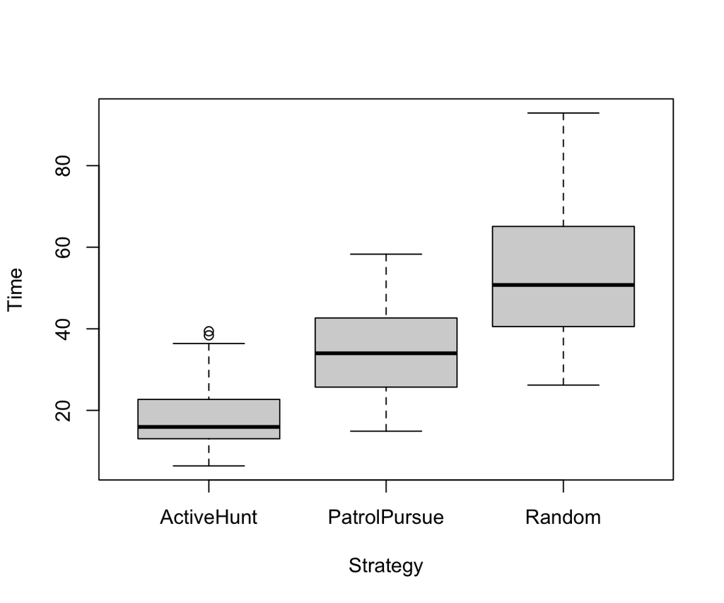

```r
game.df=read.table("strategy.txt",header=TRUE)
game.df$Strategy=as.factor(game.df$Strategy)
plot(Time ~ Strategy,data=game.df)
```

```r
summaryStats(Time ~ Strategy,data=game.df)
```

```
##              Sample Size     Mean Median   Std Dev Midspread
## ActiveHunt            60 18.39000  15.95  7.380361     9.575
## PatrolPursue          60 34.55667  34.00 11.026507    16.675
## Random                60 53.74000  50.75 18.068844    24.325
```

## Model fitting

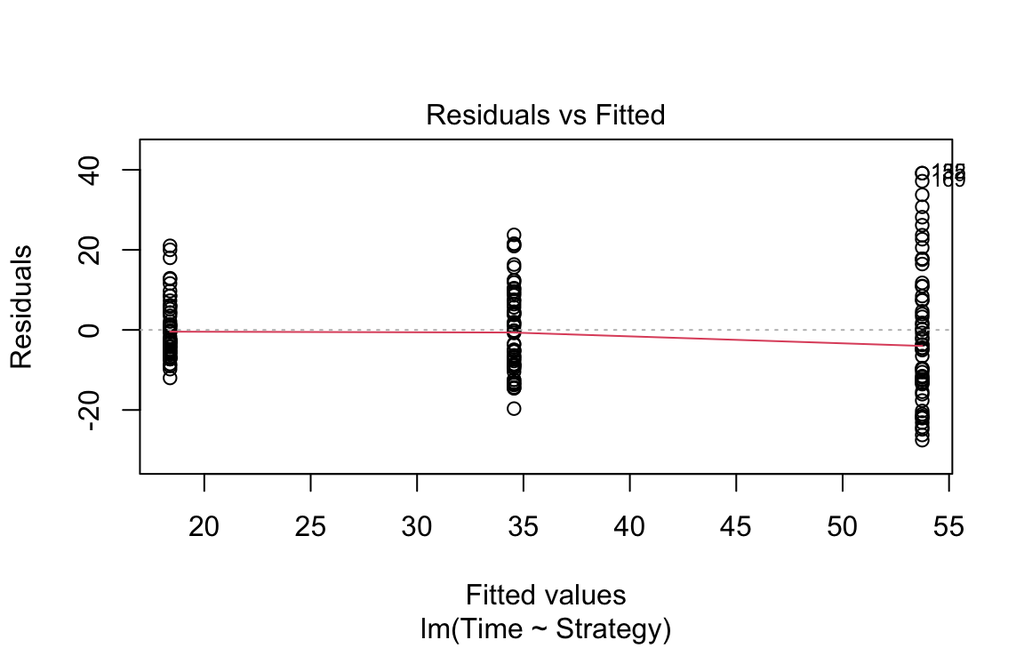

```r
game.fit <- lm(Time~ Strategy, data=game.df)
plot(game.fit, which = 1)
```

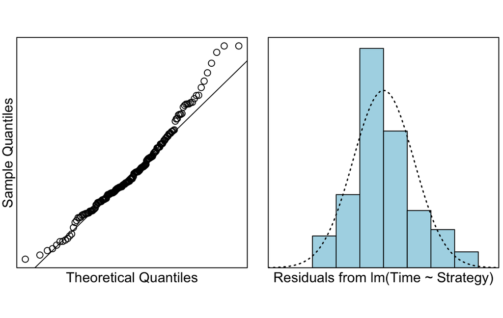

```r
normcheck(game.fit)
```

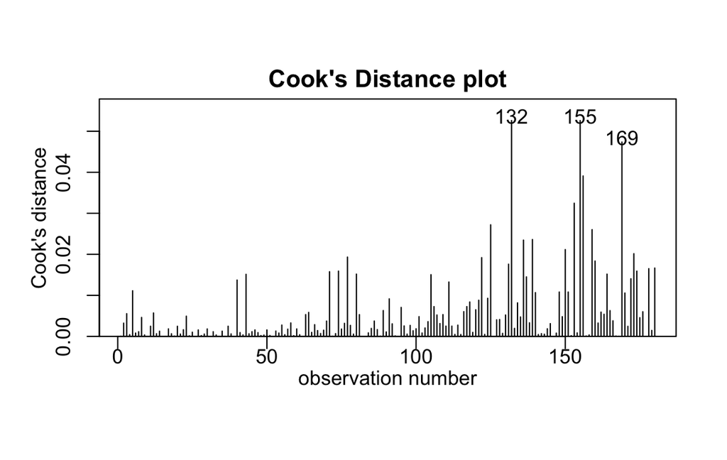

```r
cooks20x(game.fit)
```

```r
summary(game.fit)
```

```
##
## Call:
## lm(formula = Time ~ Strategy, data = game.df)
##
## Residuals:
##     Min      1Q  Median      3Q     Max
## -27.540  -8.507  -2.365   7.322  39.160
##
## Coefficients:
##                      Estimate Std. Error t value Pr(>|t|)
## (Intercept)            18.390      1.671  11.006  < 2e-16 ***
## StrategyPatrolPursue   16.167      2.363   6.842 1.23e-10 ***
## StrategyRandom         35.350      2.363  14.960  < 2e-16 ***
## ---
## Signif. codes:  0 '***' 0.001 '**' 0.01 '*' 0.05 '.' 0.1 ' ' 1
##
## Residual standard error: 12.94 on 177 degrees of freedom
## Multiple R-squared:  0.559,  Adjusted R-squared:  0.554
## F-statistic: 112.2 on 2 and 177 DF,  p-value: < 2.2e-16
```

```r
summary1way(game.fit)
```

```
## ANOVA Table:
##                 Df  Sum Squares  Mean Square  F-statistic  p-value
## Between Groups  2   37579.67778  18789.83889  112.16995    0
## Within Groups   177 29649.66533  167.51223
## Total           179 67229.34311
##
## Numeric Summary:
##               Sample size     Mean  Median  Std Dev  Midspread
## All Data              180 35.56222   31.20 19.37996     26.375
## ActiveHunt             60 18.39000   15.95  7.38036      9.575
## PatrolPursue           60 34.55667   34.00 11.02651     16.675
## Random                 60 53.74000   50.75 18.06884     24.325
##
## Table of Effects: (GrandMean and deviations from GM)
##      typ.val   ActiveHunt PatrolPursue       Random
##     35.56222    -17.17222     -1.00556     18.17778
```

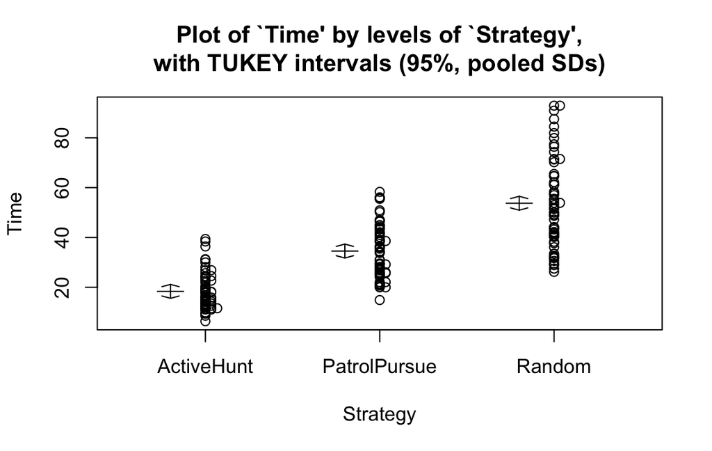

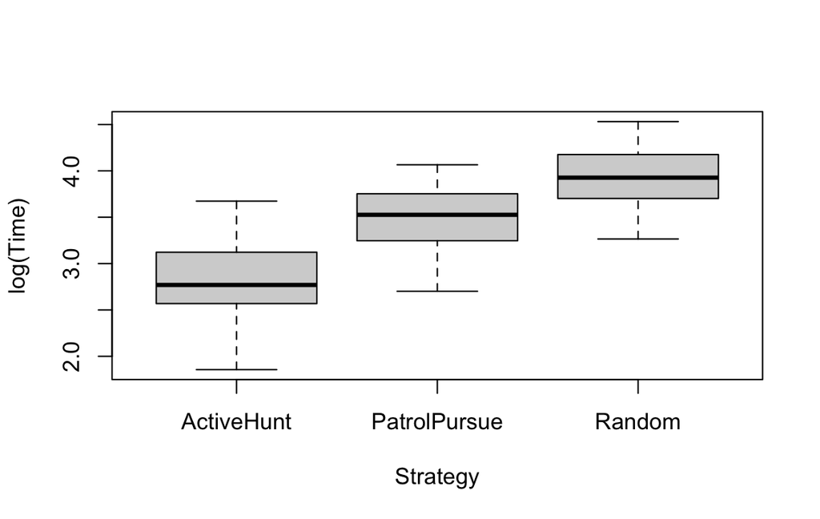

```r
#log Time, ActiveHunt baseline
game.df$Strategy <- relevel(game.df$Strategy, ref="ActiveHunt")
game.fit2 <- lm(log(Time) ~ Strategy, data=game.df)
plot(log(Time) ~ Strategy,data=game.df)
```

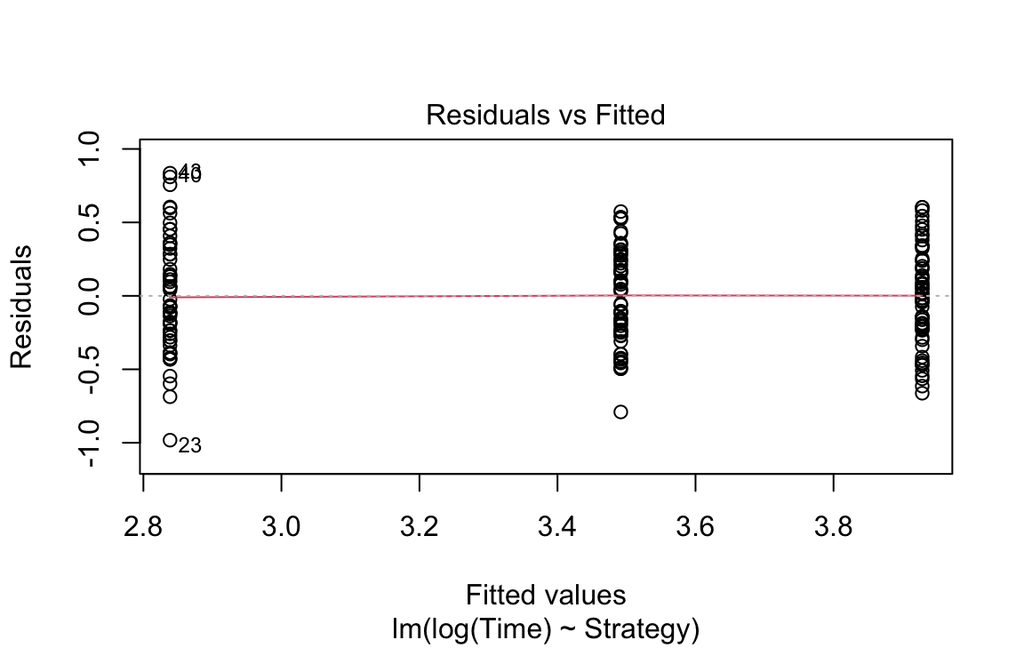

```r
plot(game.fit2, which = 1)
```

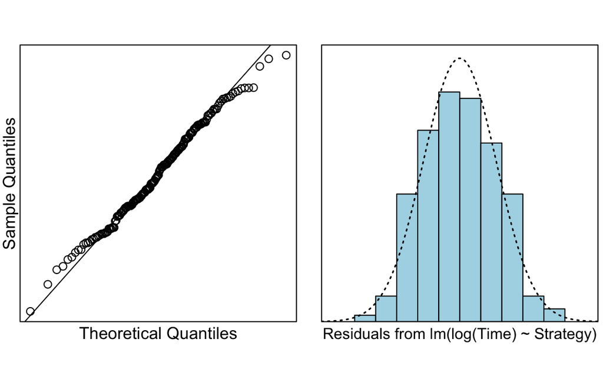

```r
normcheck(game.fit2)
```

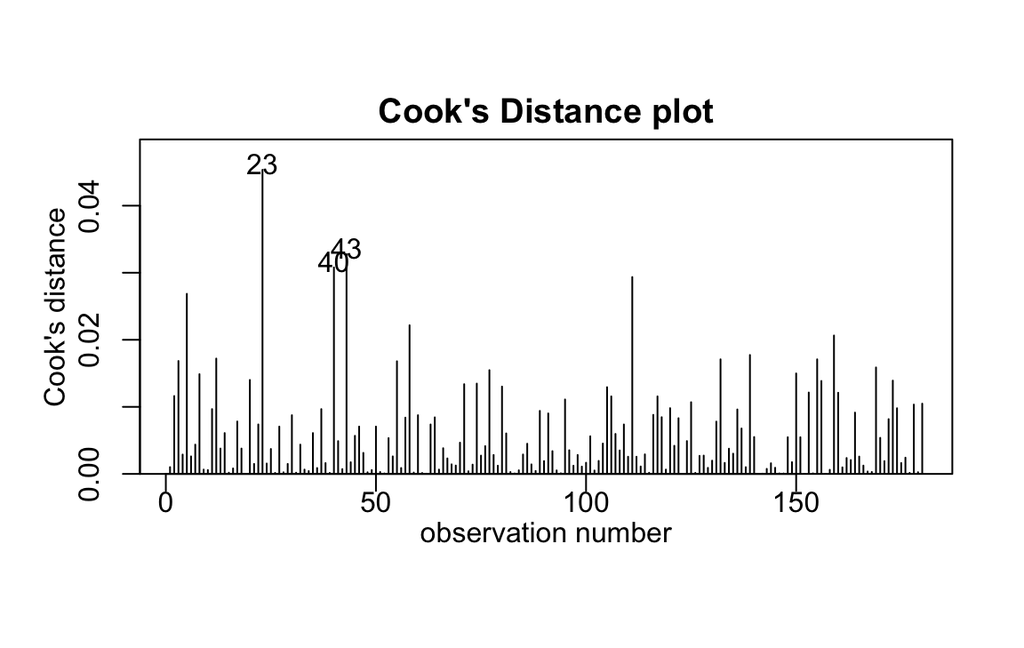

```r
cooks20x(game.fit2)
```

```r
summary(game.fit2)
```

```
##
## Call:
## lm(formula = log(Time) ~ Strategy, data = game.df)
##
## Residuals:
##      Min       1Q   Median       3Q      Max
## -0.98230 -0.23824 -0.01547  0.25869  0.83517
##
## Coefficients:
##                      Estimate Std. Error t value Pr(>|t|)
## (Intercept)           2.83860    0.04514   62.88   <2e-16 ***
## StrategyPatrolPursue  0.65314    0.06384   10.23   <2e-16 ***
## StrategyRandom        1.08990    0.06384   17.07   <2e-16 ***
## ---
## Signif. codes:  0 '***' 0.001 '**' 0.01 '*' 0.05 '.' 0.1 ' ' 1
##
## Residual standard error: 0.3497 on 177 degrees of freedom
## Multiple R-squared:  0.6253, Adjusted R-squared:  0.621
## F-statistic: 147.7 on 2 and 177 DF,  p-value: < 2.2e-16
```

```r
anova(game.fit2)
```

```
## Analysis of Variance Table
##
## Response: log(Time)
##            Df Sum Sq Mean Sq F value    Pr(>F)
## Strategy    2 36.105 18.0524  147.66 < 2.2e-16 ***
## Residuals 177 21.639  0.1223
## ---
## Signif. codes:  0 '***' 0.001 '**' 0.01 '*' 0.05 '.' 0.1 ' ' 1
```

```r
z <- summary1way(game.fit2)
```

```
## ANOVA Table:
##                 Df  Sum Squares  Mean Square  F-statistic  p-value
## Between Groups  2   36.10476     18.05238     147.65948    0
## Within Groups   177 21.63946     0.12226
## Total           179 57.74422
##
## Numeric Summary:
##               Sample size     Mean  Median  Std Dev  Midspread
## All Data              180  3.41961 3.44041  0.56797    0.83678
## ActiveHunt             60  2.83860 2.76945  0.38320    0.54790
## PatrolPursue           60  3.49174 3.52634  0.32458    0.50000
## Random                 60  3.92850 3.92683  0.33848    0.46968
##
## Table of Effects: (GrandMean and deviations from GM)
##      typ.val   ActiveHunt PatrolPursue       Random
##      3.41961     -0.58102      0.07213      0.50889
```

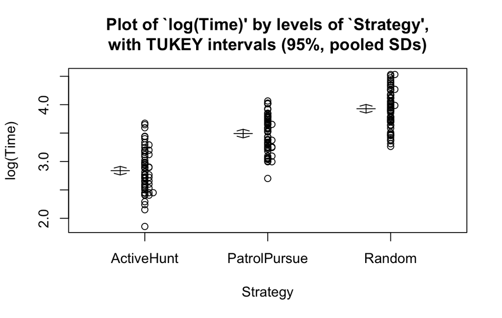

```r
x <- multipleComp(game.fit2)
x
```

```
##                               Estimate Tukey.L Tukey.U Tukey.p
## ActiveHunt  -  PatrolPursue -0.6531447 -0.8040 -0.5023       0
## ActiveHunt  -  Random       -1.0899010 -1.2408 -0.9390       0
## PatrolPursue  -  Random     -0.4367562 -0.5876 -0.2859       0
```

```r
#Confidence intervals for medians of strategies
exp(predict(game.fit2,data.frame(Strategy = c("ActiveHunt", "PatrolPursue", "Random")), interval="confidence"))
```

```
##        fit      lwr      upr
## 1 17.09175 15.63503 18.68419
## 2 32.84307 30.04388 35.90306
## 3 50.83052 46.49827 55.56640
```

```r
#Backtransformed data as percentage, ActiveHunt baseline
100 * exp(x[,1:3])
```

```
##                             Estimate  Tukey.L  Tukey.U
## ActiveHunt  -  PatrolPursue 52.04067 44.75352 60.51372
## ActiveHunt  -  Random       33.62498 28.91528 39.10187
## PatrolPursue  -  Random     64.61289 55.56593 75.13377
```

```r
#Relevel, Random baseline
game.df$Strategy <- relevel(game.df$Strategy, ref="Random")
game.fit2 <- lm(log(Time) ~ Strategy, data=game.df)
x <- multipleComp(game.fit2)

#Backtransformed data as percentage, Random baseline
100 * exp(x[,1:3])
```

```
##                              Estimate   Tukey.L   Tukey.U
## Random  -  ActiveHunt       297.39795 255.74227 345.83791
## Random  -  PatrolPursue     154.76788 133.09594 179.96640
## ActiveHunt  -  PatrolPursue  52.04067  44.75352  60.51372
```

Log transforming Time aims to remove the relationship between mean and variance between the strategies. The strategies with higher means also tend to have higher variability. Removing this relationship allows the data to conform to the assumption for ANOVA analysis, that the variance of the residuals are more homogenous. The transformation also improves the normality assumption.

## Method and Assumption Checks

We wanted to explain survival time in a video game using strategy, a factor with three levels, so we fitted a One-way ANOVA model to these data. The first model fitted was used time as a response variable, this model indicated that the equality of variance assumption was not satisfied. So we logged Time and this model assumption was satisfied, there were no unduly influential points, and all other model assumption seemed satisfied.

Our final model is

$$log(Time_i)=\beta_0 + \beta_1 \times strat.ActiveHunt_i + \beta_2 \times strat.PatrolPursue_i + \beta_3 \times strat.Random_i + \epsilon_i,$$

Where $strat.x_i$ is 1 if the player uses the strategy $x$ and $0$ otherwise, (with $x \in {ActiveHunt, PatrolPursue, Random}$), and $\epsilon_i \sim iid N(0,\sigma^2)$.

Our model explained 62.5% of the variability in the survival times.

## Executive Summary

We have evidence that the median survival time between the different strategies are not the same, (P-value $\approx 0$). We found that there were significant differences between all combinations for pairs of strategies.

The shortest survival time, in general, was obtained by players using the ActiveHunt strategy. The median survival time for the ActiveHunt strategy was estimated to be between 28.92% to 39.10% of the median Random strategy survival time, and 44.75% and 60.51% of the median PatrolPursue survival time.